# Project: Investigating The "No Show Appointments" Dataset

- Introduction
- Data Wrangling
- Exploratory Data Analysis
- Conclusions

## Introduction

```
In this project, I will be analyzing a dataset that collects information from 100k medical appointments in Brazil and is focused on the question of whether or not patients show up for their appointment. A number of characteristics about each patient are included in each row of this dataset. So, I will try to find out the factors that are most related to the     presence/ absence of patients using this analytical project.
```

### Some questions that I need to answer are:

1. Relation of Attendance to Patients' Neighbourhoods?
2. Relation of Attendance to Different types of Chronic diseases?
3. Relation of Attendance to Patients' age? Relation of Attendance to Patients' Gender?
4. Does sending an reminder SMS increase patients' attendance?
5. Relation of Attendance to Patients' Gender?
6. Do patients recieving Borsa Familia tend to attend more or less?

```python
# Upgrade pandas to use dataframe.explode() function.
!pip install --upgrade pandas==0.25.0
```

[output not shown]

```python
# Starting with importing the packages that I plan to use.

import pandas as pd
import numpy as np
import matplotlib.pyplot as plt
import seaborn as sns

%matplotlib inline
```

## Data Wrangling

### General Properties

```python
# Load my data
df = pd.read_csv("noshowappointments-kagglev2-may-2016.csv")
```

```python
#Have a look on the first 5 rows to see our dataframe
df.head()
```

|  | PatientId | AppointmentID | Gender | ScheduledDay | AppointmentDay | Age | Neighbourhood | Scholarship | Hipertension | Diabetes | Alcoholism | Handcap | SMS_received | No-show |
| --- | --- | --- | --- | --- | --- | --- | --- | --- | --- | --- | --- | --- | --- | --- |
| 0 | 2.987250e+13 | 5642903 | F | 2016-04-29T18:38:08Z | 2016-04-29T00:00:00Z | 62 | JARDIM DA PENHA | 0 | 1 | 0 | 0 | 0 | 0 | No |
| 1 | 5.589978e+14 | 5642503 | M | 2016-04-29T16:08:27Z | 2016-04-29T00:00:00Z | 56 | JARDIM DA PENHA | 0 | 0 | 0 | 0 | 0 | 0 | No |
| 2 | 4.262962e+12 | 5642549 | F | 2016-04-29T16:19:04Z | 2016-04-29T00:00:00Z | 62 | MATA DA PRAIA | 0 | 0 | 0 | 0 | 0 | 0 | No |
| 3 | 8.679512e+11 | 5642828 | F | 2016-04-29T17:29:31Z | 2016-04-29T00:00:00Z | 8 | PONTAL DE CAMBURI | 0 | 0 | 0 | 0 | 0 | 0 | No |
| 4 | 8.841186e+12 | 5642494 | F | 2016-04-29T16:07:23Z | 2016-04-29T00:00:00Z | 56 | JARDIM DA PENHA | 0 | 1 | 1 | 0 | 0 | 0 | No |

```python
#Inspect number of columns and rows(a.k.a entries)
df.shape
```

```
(110527, 14)
```

```python
#More in-depth data
df.describe()
```

|  | PatientId | AppointmentID | Age | Scholarship | Hipertension | Diabetes | Alcoholism | Handcap | SMS_received |
| --- | --- | --- | --- | --- | --- | --- | --- | --- | --- |
| count | 1.105270e+05 | 1.105270e+05 | 110527.000000 | 110527.000000 | 110527.000000 | 110527.000000 | 110527.000000 | 110527.000000 | 110527.000000 |
| mean | 1.474963e+14 | 5.675305e+06 | 37.088874 | 0.098266 | 0.197246 | 0.071865 | 0.030400 | 0.022248 | 0.321026 |
| std | 2.560949e+14 | 7.129575e+04 | 23.110205 | 0.297675 | 0.397921 | 0.258265 | 0.171686 | 0.161543 | 0.466873 |
| min | 3.921784e+04 | 5.030230e+06 | -1.000000 | 0.000000 | 0.000000 | 0.000000 | 0.000000 | 0.000000 | 0.000000 |
| 25% | 4.172614e+12 | 5.640286e+06 | 18.000000 | 0.000000 | 0.000000 | 0.000000 | 0.000000 | 0.000000 | 0.000000 |
| 50% | 3.173184e+13 | 5.680573e+06 | 37.000000 | 0.000000 | 0.000000 | 0.000000 | 0.000000 | 0.000000 | 0.000000 |
| 75% | 9.439172e+13 | 5.725524e+06 | 55.000000 | 0.000000 | 0.000000 | 0.000000 | 0.000000 | 0.000000 | 1.000000 |
| max | 9.999816e+14 | 5.790484e+06 | 115.000000 | 1.000000 | 1.000000 | 1.000000 | 1.000000 | 4.000000 | 1.000000 |

```python
#info about each column to view types and empty cells
df.info()
```

```
<class 'pandas.core.frame.DataFrame'>
RangeIndex: 110527 entries, 0 to 110526
Data columns (total 14 columns):
PatientId         110527 non-null float64
AppointmentID     110527 non-null int64
Gender            110527 non-null object
ScheduledDay      110527 non-null object
AppointmentDay    110527 non-null object
Age               110527 non-null int64
Neighbourhood     110527 non-null object
Scholarship       110527 non-null int64
Hipertension      110527 non-null int64
Diabetes          110527 non-null int64
Alcoholism        110527 non-null int64
Handcap           110527 non-null int64
SMS_received      110527 non-null int64
No-show           110527 non-null object
dtypes: float64(1), int64(8), object(5)
memory usage: 11.8+ MB
```

```python
#Checking for duplicates
df.duplicated().sum()
```

```
0
```

```python
df.duplicated('PatientId').sum()
```

```
48228
```

```python
df.duplicated('AppointmentID').sum()
```

```
0
```

###### This dataset has precisely 110527 entries (with no empty cells), and 14 columns including the patients ID, gender, age, neighbourhood, hypertension, diabetes and others.

###### There are Patient Id duplicates , but no duplicated appointment Id's which means that same patient got more than an appointment,and that's ok. No duplicated rows in the dataset.

###### There are some errors though that must be cleaned, for example the minimum age is -1 which ,obviously, doesn't make sense.

###### Now, I will make some changes to the column names, firstly for consistency

### Data Cleaning

```python
#rename some misspelled column names, and also I'll change the No-show to Show, which will be easier in tackling the dataset
df.rename( columns = {'Hipertension':'Hypertension','Handcap': 'Handicapped','No-show':'Attended'},inplace=True )
df.head()
```

|  | PatientId | AppointmentID | Gender | ScheduledDay | AppointmentDay | Age | Neighbourhood | Scholarship | Hypertension | Diabetes | Alcoholism | Handicapped | SMS_received | Attended |
| --- | --- | --- | --- | --- | --- | --- | --- | --- | --- | --- | --- | --- | --- | --- |
| 0 | 2.987250e+13 | 5642903 | F | 2016-04-29T18:38:08Z | 2016-04-29T00:00:00Z | 62 | JARDIM DA PENHA | 0 | 1 | 0 | 0 | 0 | 0 | No |
| 1 | 5.589978e+14 | 5642503 | M | 2016-04-29T16:08:27Z | 2016-04-29T00:00:00Z | 56 | JARDIM DA PENHA | 0 | 0 | 0 | 0 | 0 | 0 | No |
| 2 | 4.262962e+12 | 5642549 | F | 2016-04-29T16:19:04Z | 2016-04-29T00:00:00Z | 62 | MATA DA PRAIA | 0 | 0 | 0 | 0 | 0 | 0 | No |
| 3 | 8.679512e+11 | 5642828 | F | 2016-04-29T17:29:31Z | 2016-04-29T00:00:00Z | 8 | PONTAL DE CAMBURI | 0 | 0 | 0 | 0 | 0 | 0 | No |
| 4 | 8.841186e+12 | 5642494 | F | 2016-04-29T16:07:23Z | 2016-04-29T00:00:00Z | 56 | JARDIM DA PENHA | 0 | 1 | 1 | 0 | 0 | 0 | No |

```python
#for consistency and ease of analysis, replace yes and no no show, to Binary (0 and 1)
df.Attended.replace(['No', 'Yes'], [1, 0], inplace=True)
```

```python
#Will drop some columns, these have zero effect on my data analysis
df.drop(['PatientId','AppointmentID','ScheduledDay'],axis=1,inplace=True)
df.head(1)
```

|  | Gender | AppointmentDay | Age | Neighbourhood | Scholarship | Hypertension | Diabetes | Alcoholism | Handicapped | SMS_received | Attended |
| --- | --- | --- | --- | --- | --- | --- | --- | --- | --- | --- | --- |
| 0 | F | 2016-04-29T00:00:00Z | 62 | JARDIM DA PENHA | 0 | 1 | 0 | 0 | 0 | 0 | 1 |

```python
#searching for the reason behind the minimum age of -1 that we found earlier
df.index[df['Age'] <0]
```

```
Int64Index([99832], dtype='int64')
```

```python
#Now, I will delete this row( 1 entry will not affect my results)
df.drop([99832],inplace=True)
df.describe()
```

|  | Age | Scholarship | Hypertension | Diabetes | Alcoholism | Handicapped | SMS_received | Attended |
| --- | --- | --- | --- | --- | --- | --- | --- | --- |
| count | 110526.000000 | 110526.000000 | 110526.000000 | 110526.000000 | 110526.000000 | 110526.000000 | 110526.000000 | 110526.000000 |
| mean | 37.089219 | 0.098266 | 0.197248 | 0.071865 | 0.030400 | 0.022248 | 0.321029 | 0.798066 |
| std | 23.110026 | 0.297676 | 0.397923 | 0.258266 | 0.171686 | 0.161543 | 0.466874 | 0.401445 |
| min | 0.000000 | 0.000000 | 0.000000 | 0.000000 | 0.000000 | 0.000000 | 0.000000 | 0.000000 |
| 25% | 18.000000 | 0.000000 | 0.000000 | 0.000000 | 0.000000 | 0.000000 | 0.000000 | 1.000000 |
| 50% | 37.000000 | 0.000000 | 0.000000 | 0.000000 | 0.000000 | 0.000000 | 0.000000 | 1.000000 |
| 75% | 55.000000 | 0.000000 | 0.000000 | 0.000000 | 0.000000 | 0.000000 | 1.000000 | 1.000000 |
| max | 115.000000 | 1.000000 | 1.000000 | 1.000000 | 1.000000 | 4.000000 | 1.000000 | 1.000000 |

## Exploratory Data Analysis

#### Starting with general exploration of the whole dataset

```python
#I will make new dataframes for showing and not showing up.

Show= df[df['Attended'] == 1]
Noshow= df[df['Attended'] == 0]
```

```python
#indepth exploration of Attending patients
Show.describe()
```

|  | Age | Scholarship | Hypertension | Diabetes | Alcoholism | Handicapped | SMS_received | Attended |
| --- | --- | --- | --- | --- | --- | --- | --- | --- |
| count | 88207.000000 | 88207.000000 | 88207.000000 | 88207.000000 | 88207.000000 | 88207.000000 | 88207.000000 | 88207.0 |
| mean | 37.790504 | 0.093904 | 0.204394 | 0.073838 | 0.030417 | 0.022742 | 0.291337 | 1.0 |
| std | 23.338645 | 0.291697 | 0.403261 | 0.261508 | 0.171733 | 0.162751 | 0.454381 | 0.0 |
| min | 0.000000 | 0.000000 | 0.000000 | 0.000000 | 0.000000 | 0.000000 | 0.000000 | 1.0 |
| 25% | 18.000000 | 0.000000 | 0.000000 | 0.000000 | 0.000000 | 0.000000 | 0.000000 | 1.0 |
| 50% | 38.000000 | 0.000000 | 0.000000 | 0.000000 | 0.000000 | 0.000000 | 0.000000 | 1.0 |
| 75% | 56.000000 | 0.000000 | 0.000000 | 0.000000 | 0.000000 | 0.000000 | 1.000000 | 1.0 |
| max | 115.000000 | 1.000000 | 1.000000 | 1.000000 | 1.000000 | 4.000000 | 1.000000 | 1.0 |

```python
#indepth exploration of non-attending patients
Noshow.describe()
```

|  | Age | Scholarship | Hypertension | Diabetes | Alcoholism | Handicapped | SMS_received | Attended |
| --- | --- | --- | --- | --- | --- | --- | --- | --- |
| count | 22319.000000 | 22319.000000 | 22319.000000 | 22319.000000 | 22319.000000 | 22319.000000 | 22319.000000 | 22319.0 |
| mean | 34.317667 | 0.115507 | 0.169004 | 0.064071 | 0.030333 | 0.020297 | 0.438371 | 0.0 |
| std | 21.965941 | 0.319640 | 0.374764 | 0.244885 | 0.171505 | 0.156670 | 0.496198 | 0.0 |
| min | 0.000000 | 0.000000 | 0.000000 | 0.000000 | 0.000000 | 0.000000 | 0.000000 | 0.0 |
| 25% | 16.000000 | 0.000000 | 0.000000 | 0.000000 | 0.000000 | 0.000000 | 0.000000 | 0.0 |
| 50% | 33.000000 | 0.000000 | 0.000000 | 0.000000 | 0.000000 | 0.000000 | 0.000000 | 0.0 |
| 75% | 51.000000 | 0.000000 | 0.000000 | 0.000000 | 0.000000 | 0.000000 | 1.000000 | 0.0 |
| max | 115.000000 | 1.000000 | 1.000000 | 1.000000 | 1.000000 | 4.000000 | 1.000000 | 0.0 |

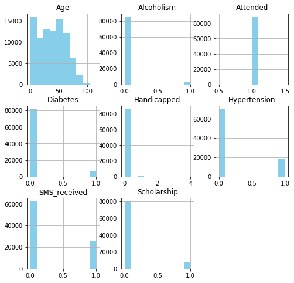

```python
#Visualization of data of Attending Patients
Show.hist(figsize=(8,8), color='skyblue');
```

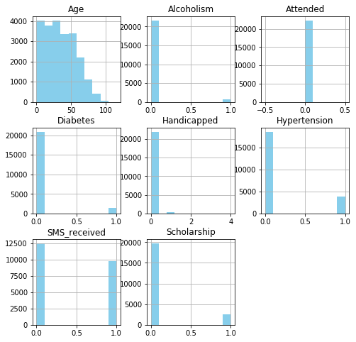

```python
#Visualization of data of non-attending patients
Noshow.hist(figsize=(8,8),color='skyblue');
```

## Relation between Attendance and Neighbourhood

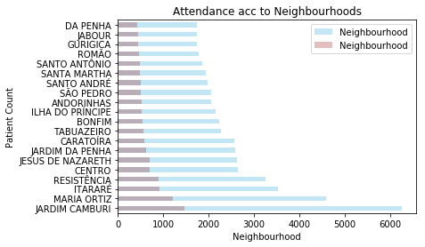

```python
Show.Neighbourhood.value_counts().nlargest(20).plot(kind='barh',alpha=0.5,color='skyblue')
Noshow.Neighbourhood.value_counts().nlargest(20).plot(kind='barh',alpha=0.3,color='brown')
plt.title('Attendance acc to Neighbourhoods')
plt.xlabel('Neighbourhood')
plt.ylabel('Patient Count')
plt.legend();
```

## Relation between Attendance and Chronic Diseases

```python
# I will make a function to prevent repetition of same code with variable diseases.

def Attendance(Disease):
    pd.crosstab(df[Disease], df.Attended, normalize='columns').plot(kind='bar',alpha = 0.5, colormap='Paired')
    plt.title('Proportion of Attendance in {} patients'.format(Disease))
    plt.xlabel('{}'.format(Disease))
    plt.ylabel('Proportion')
    return plt.show();
```

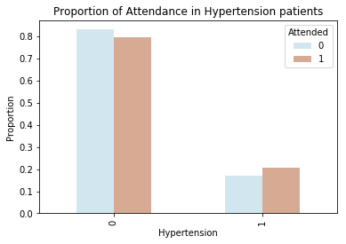

```python
Attendance('Hypertension')
```

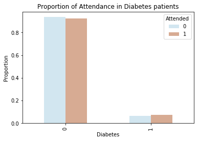

```python
Attendance('Diabetes')
```

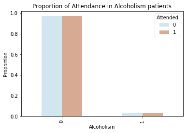

```python
Attendance('Alcoholism')
```

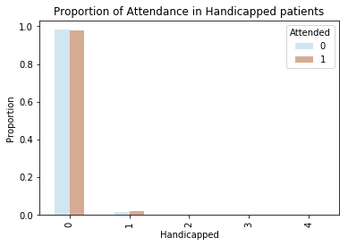

```python
Attendance('Handicapped')
```

##### So, Hypertension and Diabetes Patients tend to show up more,

##### but Alcoholism and being Handicapped does not have an obvious effect on showing up

## Relation between Attendance and Patients' Age

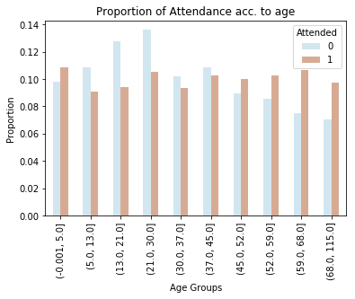

```python
#will use a new dataframe with age groups rather than plotting against every 1 year.

df['Age_group'] = pd.qcut(df.Age, 10)

pd.crosstab(df['Age_group'], df.Attended, normalize='columns').plot(kind='bar',alpha=0.5, colormap='Paired')
plt.title('Proportion of Attendance acc. to age')
plt.xlabel('Age Groups')
plt.ylabel('Proportion')

plt.show();
```

#### The data shows that patients age group 5 to 45 has higher incidence of No Show with a peak of non attendance in the 21 to 30 age group. While patients less than 5 years old and older than 45 tend to show up on their appointments more.

## Relation between Attendance and receiving an SMS

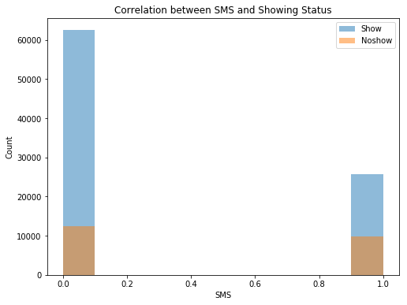

```python
fig, ax = plt.subplots(figsize=(8, 6))
ax.hist(Show['SMS_received'], alpha =0.5, label = 'Show')
ax.hist(Noshow['SMS_received'], alpha =0.5, label = 'Noshow')
ax.set_title('Correlation between SMS and Showing Status')
ax.set_xlabel('SMS')
ax.set_ylabel('Count')
ax.legend(loc='upper right')
plt.show()
```

## Relation between Attendance and Patients' Gender

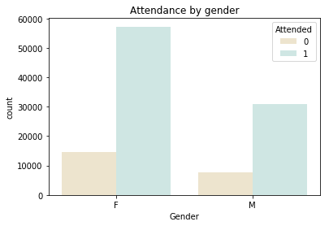

```python
ax = sns.countplot(x=df.Gender,hue=df.Attended, alpha=0.5, palette ='BrBG')
ax.set_title('Attendance by gender')
plt.show();
```

## Relation between Attendance and Scholarship enrollment

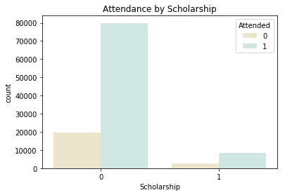

```python
ax = sns.countplot(x=df.Scholarship,hue=df.Attended, alpha=0.5, data= df, palette='BrBG')
ax.set_title('Attendance by Scholarship')
plt.show();
```

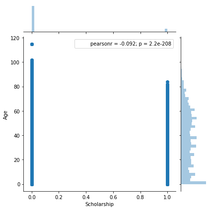

```python
#findout relation between scholarship and age
sns.jointplot(data=df, x = df['Scholarship'], y = df['Age']);
```

###### Patients who are enrolled in this scholarship are less likely to attend their appointments, while those who don't recieve those scholarships are more likely to show up.

```python
#Grouping all chronic diseases in one new dataframe

df['ChronicDis']=df['Hypertension']+df['Diabetes']+df['Handicapped']+df['Alcoholism']
```

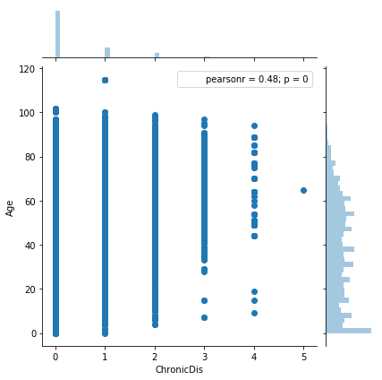

```python
#Plotting 2 variables against each other
#Age against Chronic Diseases

sns.jointplot(data=df, x = df['ChronicDis'], y = df['Age']);
```

## Conclusions

#### Limitations:

1. SMS data is not enough as it has been sent to less than half of the patients.
2. The data taken is taken over a very limited time frame, so can't be enough to make predictions of future non-showing patients.

```python
from subprocess import call
call(['python', '-m', 'nbconvert', 'Investigate_a_Dataset.ipynb'])
```

```
255
```